Datos públicos reales · Superintendencia Financiera de Colombia vía datos.gov.co · informe generado automáticamente con R

DIANA RODRÍGUEZ← Todos los bancos

INFORME MENSUAL · NOVIEMBRE 2026

# Banco Unión: colocación de crédito

$16,0 mil millones

desembolsado en noviembre 2026

-73,3 %

frente a octubre 2026

0,06 %

del mercado · puesto 29 de 29

26,42 %

tasa ponderada E.A. (mercado 19,64 %)

## Lectura del mes

- En noviembre 2026, **Banco Unión** desembolsó **$16,0 mil millones** en 2.654 créditos, una caída de 73,3 % frente a octubre 2026.
- Tiene el **0,06 %** de lo desembolsado por los bancos y ocupa el puesto 29 de 29. Desde enero 2026 su participación se mantiene estable.
- Su principal línea es **Consumo**, con el 89,9 % de su monto; ahí tiene el 0,16 % del mercado.
- Cobra más que el promedio del mercado en **Consumo** (+5,05 pp) y **Vivienda** (+3,83 pp).

La tasa total depende de la mezcla de productos: un banco con más consumo tendrá una tasa promedio más alta. Por eso la comparación justa es por tipo de crédito, en la segunda gráfica.

## Participación en el mercado, mes a mes

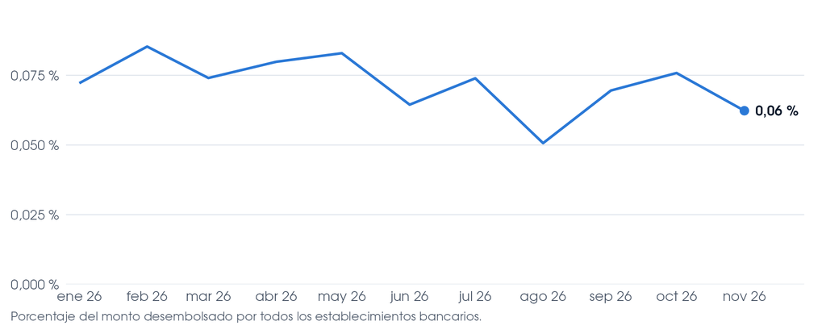

## Tasa por tipo de crédito: Banco Unión frente al mercado

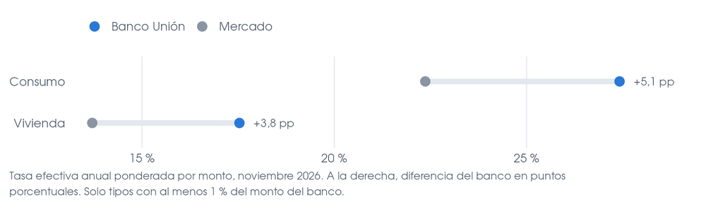

## En qué presta

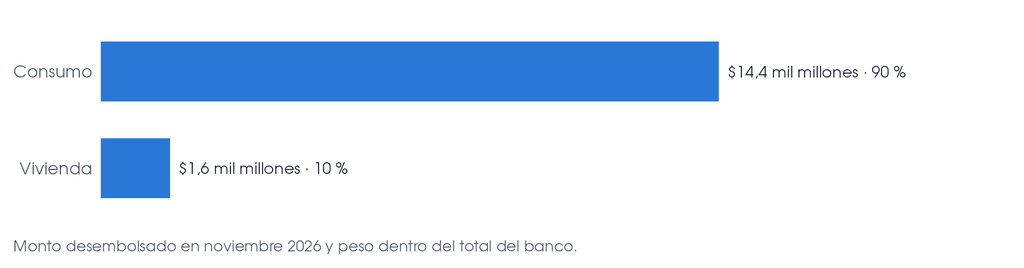

## Principales productos del mes

| Producto | Monto | Participación en el producto | Tasa banco | Tasa mercado | Diferencia |
| --- | --- | --- | --- | --- | --- |
| Crédito rotativo | $12,5 mil millones | 4,0 % | 28,17 % | 26,67 % | +1,50 pp |
| Libranza otros | $1,4 mil millones | 0,16 % | 20,80 % | 18,43 % | +2,38 pp |
| Adquisición de vivienda no vis (colocación en pesos) | $878 millones | 0,31 % | 18,00 % | 15,50 % | +2,50 pp |
| Adquisición de vivienda vis (colocación en pesos) | $733 millones | 0,34 % | 16,98 % | 14,55 % | +2,43 pp |
| Tarjeta de crédito para ingresos superiores a 2 smmlv | $214 millones | 0,00 % | 26,67 % | 22,13 % | +4,54 pp |
| Tarjeta de crédito para ingresos hasta 2 smmlv | $152 millones | 0,02 % | 26,67 % | 23,78 % | +2,89 pp |
| Libre inversión | $128 millones | 0,01 % | 26,14 % | 22,45 % | +3,68 pp |

## Cómo se hizo

Este informe se escribe solo. Un script en R lee los datos que el Monitor de mercado descarga de la Superintendencia Financiera, calcula los indicadores y redacta el texto con reglas: por ejemplo, señala un tipo de crédito como «más caro que el mercado» cuando la diferencia supera 2 puntos y pesa al menos el 5 % del banco. Con R Markdown se genera un informe por cada banco, con los mismos parámetros. GitHub Actions lo vuelve a producir cada vez que llegan datos nuevos.

Montos en pesos corrientes. Tasas efectivas anuales ponderadas por el monto desembolsado. Cifras de enero 2026 a noviembre 2026; el último mes puede ajustarse cuando la Superintendencia publique correcciones. [Ver el código en GitHub →](https://github.com/dsrodriguezq/dsrodriguezq.github.io/tree/main/proyectos/informe-bancos-r)